# Pruning & Rooting Phylogenetic Trees with ggTree

Liangzi

2025-03-28

# Before you start

## Timing of this script

```r
# What time did we start running this script?
start_time <- Sys.time()
```

## Set my seed

```r
# Any number can be chosen
set.seed(238428)
```

## Load Packages

```r
if (!requireNamespace("BiocManager", quietly = TRUE)) {
    install.packages("BiocManager")
}
BiocManager::install("phylobase")
pacman::p_load(tidyverse, phyloseq, ggtree, phytools, tidytree, phylobase,
               install = FALSE)
```

## 1. Load Data files

```r
# Preprocessed phyloseq object
load("data/03_PreProcessing/raw_preprocessed_physeq.RData")

# Inspect the phyloseq object
raw_preprocessed_physeq
```

```
## phyloseq-class experiment-level object
## otu_table()   OTU Table:         [ 2115 taxa and 19 samples ]
## sample_data() Sample Data:       [ 19 samples by 39 sample variables ]
## tax_table()   Taxonomy Table:    [ 2115 taxa by 9 taxonomic ranks ]
```

```r
# Load in the tree!
unrooted_tree <- read.tree("data/04_PhylogeneticTree/ASVs_unrooted.tree")

# Take a look at the tree
unrooted_tree
```

```
##
## Phylogenetic tree with 2115 tips and 2113 internal nodes.
##
## Tip labels:
##   ASV_0171, ASV_1365, ASV_2117, ASV_0670, ASV_1049, ASV_1264, ...
## Node labels:
##   , 0.783, 0.949, 0.892, 0.910, 0.889, ...
##
## Unrooted; includes branch length(s).
```

```r
str(unrooted_tree)
```

```
## List of 5
##  $ edge       : int [1:4227, 1:2] 2116 2116 2117 2118 2119 2120 2120 2119 2121 2122 ...
##  $ edge.length: num [1:4227] 0.00054 0.00264 0.00742 0.01143 0.02548 ...
##  $ Nnode      : int 2113
##  $ node.label : chr [1:2113] "" "0.783" "0.949" "0.892" ...
##  $ tip.label  : chr [1:2115] "ASV_0171" "ASV_1365" "ASV_2117" "ASV_0670" ...
##  - attr(*, "class")= chr "phylo"
##  - attr(*, "order")= chr "cladewise"
```

# 2. Merge Unrooted Tree & `raw_preprocessed_physeq`

```r
# Intuition check
stopifnot(ntaxa(raw_preprocessed_physeq) == ntaxa(unrooted_tree))
# No news is good news!

# Merge the tree with the phyloseq object
unrooted_physeq <-
  merge_phyloseq(raw_preprocessed_physeq, unrooted_tree)
```

[output not shown]

[output not shown]

[output not shown]

[output not shown]

[output not shown]

[output not shown]

[output not shown]

[output not shown]

[output not shown]

[output not shown]

[output not shown]

[output not shown]

[output not shown]

[output not shown]

```r
# Let's take a look!
unrooted_physeq
```

```
## phyloseq-class experiment-level object
## otu_table()   OTU Table:         [ 2115 taxa and 19 samples ]
## sample_data() Sample Data:       [ 19 samples by 39 sample variables ]
## tax_table()   Taxonomy Table:    [ 2115 taxa by 9 taxonomic ranks ]
## phy_tree()    Phylogenetic Tree: [ 2115 tips and 2113 internal nodes ]
```

# 3. Visualize and inspect tree with [ggtree](https://besjournals.onlinelibrary.wiley.com/doi/full/10.1111/2041-210X.12628).

## Kingdom Level Tree

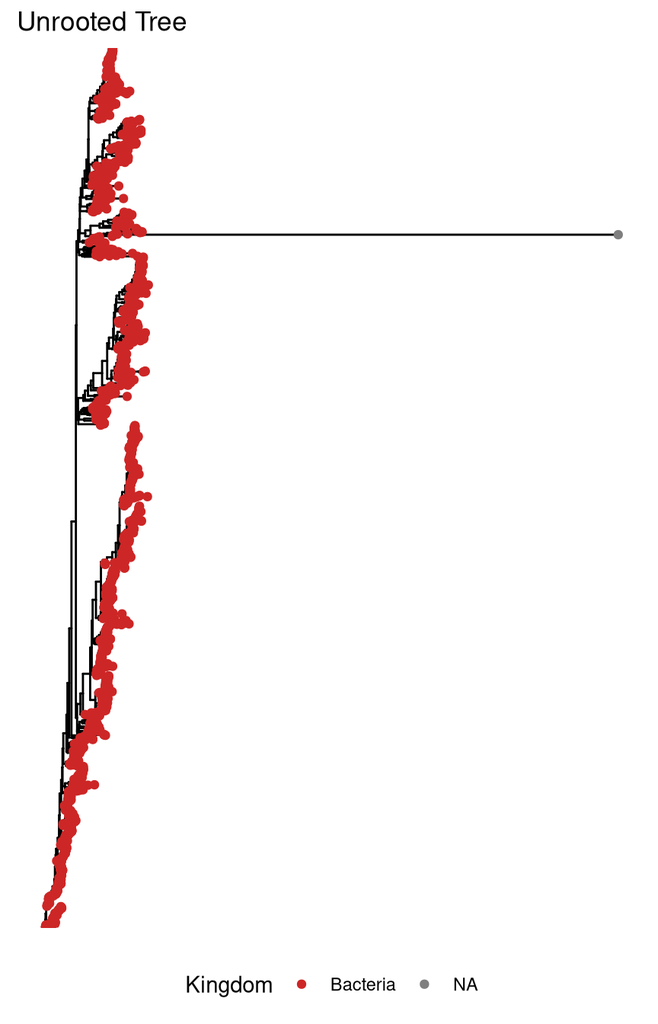

```r
# Make a basic tree with the domains
kingdom_tree <-
  ggtree(unrooted_physeq) +
  # color tips by kingdom
  geom_tippoint(mapping = aes(color = Kingdom)) +
  # add a title
  labs(title = "Unrooted Tree") +
  scale_color_manual(values = c("firebrick3", "cornflowerblue", "grey")) +
  # Move the legend to the bottom of the tree
  theme(legend.position = "bottom")

# Look at it
kingdom_tree
```

```r
# Check if tree is rooted
is.rooted(unrooted_tree) # should be TRUE
```

```
## [1] FALSE
```

# 4. Long Branches?

The dataset does not have Archaea.

**INTERPRETATION #1: Are there any suspect branches in the raw, unrooted tree? Or does your tree look “clean”? Why or why not?** The unrooted tree contains a very long branch extending to the right. This indicates that there are outlier ASVs with disproportionately high evolutionary distances compared to the rest of the tree. This could result from sequencing errors, chimeric sequences, or contamination.

## 4a. Evaluate Long Branches

### Kingdom Tree with Node Labels

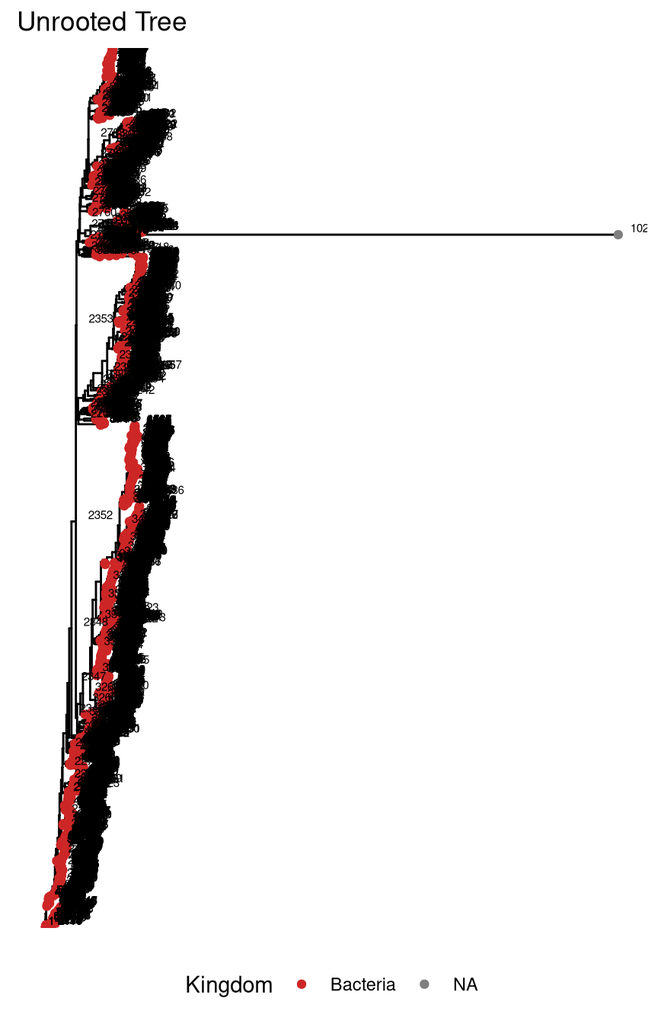

```r
kingdom_node_tree <-
  kingdom_tree +
  # Add the node label
  geom_text(aes(label=node), hjust= -0.5, vjust = -0.3, size = 2)

# Plot the tree
kingdom_node_tree
```

In the phylogeny above, it looks like node #1020 is quite long. Otherwise, things look mostly good.

### Evaluate node #1020

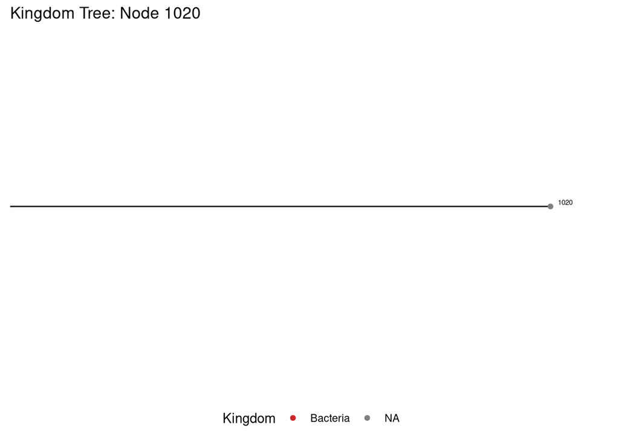

```r
# View a specific clade
# Zoom in on node that looks potentially suspicious
viewClade(kingdom_node_tree +
          labs(title = "Kingdom Tree: Node 1020"),
          node = 1020)
```

```r
tidytree::ancestor(unrooted_tree, 1020) # The input is the TREE, not phyloseq!!
```

```
##  [1] 3159 3158 3157 3156 3155 3154 2760 2759 2758 2353 2352 2348 2347 2346 2335
## [16] 2334 2274 2269 2268 2188 2187 2180 2179 2178 2177 2176 2175 2174 2173 2172
## [31] 2170 2169 2168 2167 2166 2165 2164 2163 2162 2118 2117 2116
```

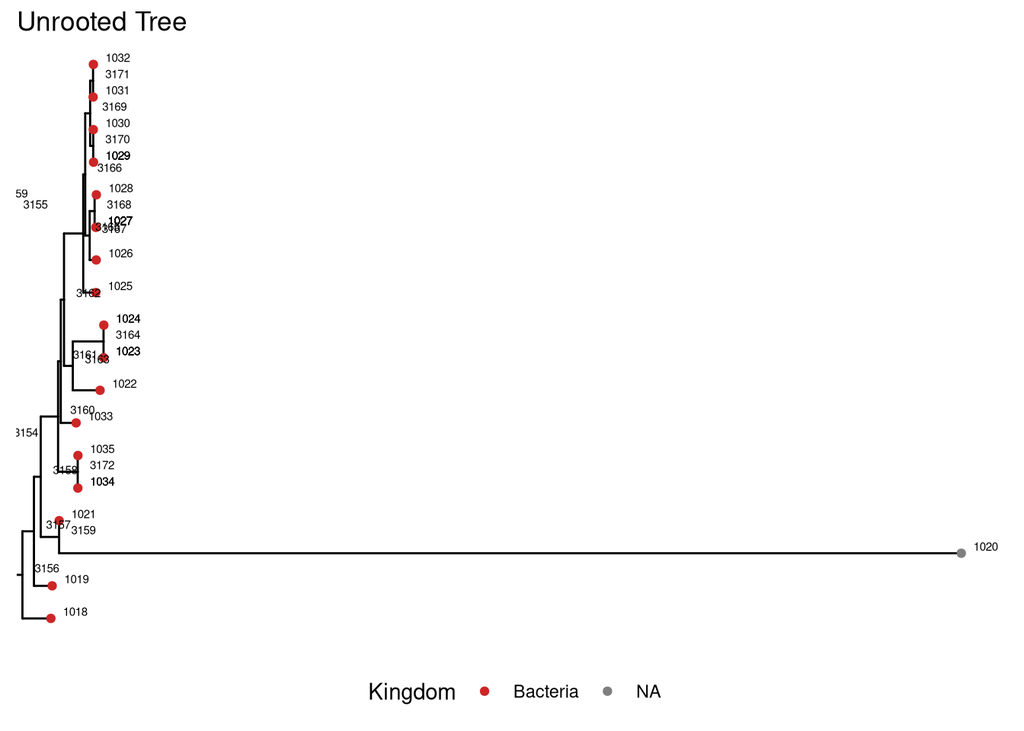

```r
# Let's evaluate 3156
viewClade(kingdom_node_tree, 3156) # even more zoomed out
```

```r
# Or if there are two nodes that we can see we can find its MRCA
## create tibble of tree to identify offspring
tree_tib <- as_tibble(unrooted_physeq@phy_tree)

# Inspect
head(tree_tib)
```

```
## # A tibble: 6 × 4
##   parent  node branch.length label
##    <int> <int>         <dbl> <chr>
## 1   2116     1       0.00054 ASV_0171
## 2   2120     2       0.0286  ASV_1365
## 3   2120     3       0.0670  ASV_2117
## 4   2123     4       0.00197 ASV_0670
## 5   2123     5       0.00054 ASV_1049
## 6   2126     6       0.0104  ASV_1264
```

```r
str(tree_tib)
```

```
## tbl_tree [4,228 × 4] (S3: tbl_tree/tbl_df/tbl/data.frame)
##  $ parent       : int [1:4228] 2116 2120 2120 2123 2123 2126 2127 2128 2128 2130 ...
##  $ node         : int [1:4228] 1 2 3 4 5 6 7 8 9 10 ...
##  $ branch.length: num [1:4228] 0.00054 0.02859 0.06695 0.00197 0.00054 ...
##  $ label        : chr [1:4228] "ASV_0171" "ASV_1365" "ASV_2117" "ASV_0670" ...
```

```r
# lets look at the long branch
mrca_node_1020 <- tidytree::MRCA(unrooted_tree, .node1 = 1020, .node2 = 1021)

# Inspect
mrca_node_1020
```

```
## [1] 3159
```

```r
## create dataframe to view ASVs and taxa info and to pull the ASVs
node_3159 <-
  offspring(tree_tib, mrca_node_1020, tiponly = TRUE) %>%
  as.data.frame() %>%
  pull(label)

# Inspect
node_3159
```

```
## [1] "ASV_1878" "ASV_1910"
```

```r
# Now, let's pull out the taxonomy information, including the ASV sequence!
node_3159_df <-
  unrooted_physeq %>%
  tax_table() %>%
  as.data.frame() %>%
  filter(ASV %in% node_3159)

# Take a look:
glimpse(node_3159_df)
```

```
## Rows: 2
## Columns: 9
## $ Kingdom <chr> "Eukaryota", "Bacteria"
## $ Phylum  <chr> NA, "Planctomycetota"
## $ Class   <chr> NA, "Phycisphaerae"
## $ Order   <chr> NA, "Pla1 lineage"
## $ Family  <chr> NA, NA
## $ Genus   <chr> NA, NA
## $ Species <chr> NA, NA
## $ ASV     <chr> "ASV_1878", "ASV_1910"
## $ ASVseqs <chr> "ACTTCTGGGAGGAAAGCTGATCGCCCTGCAGAATACCGATCCAACGCATGGTTACAAAGTC…
```

```r
# look at counts of the ASVs
unrooted_physeq %>%
  subset_taxa(., ASV %in% node_3159_df$ASV) %>%
  otu_table() %>%
  data.frame() %>%
  colSums()
```

[output not shown]

[output not shown]

[output not shown]

[output not shown]

[output not shown]

[output not shown]

[output not shown]

[output not shown]

```
## SRR12873300 SRR12873301 SRR12873302 SRR12873303 SRR12873304 SRR12873305
##           0           0           0           0           0           0
## SRR12873306 SRR12873316 SRR12873318 SRR12873319 SRR12873320 SRR12873321
##           0           0           0           0           0           4
## SRR12873322 SRR12873323 SRR12873324 SRR12873325 SRR12873326 SRR12873327
##           0           0           0           0           0           0
## SRR12873328
##           0
```

```r
# Lets BLAST our sequences to investigate if they are real or not
node_3159_df
```

```
##            Kingdom          Phylum         Class        Order Family Genus
## ASV_1878 Eukaryota            <NA>          <NA>         <NA>   <NA>  <NA>
## ASV_1910  Bacteria Planctomycetota Phycisphaerae Pla1 lineage   <NA>  <NA>
##          Species      ASV
## ASV_1878    <NA> ASV_1878
## ASV_1910    <NA> ASV_1910
##                                                                                                                                                                                                                                                                                                          …
## ASV_1878  ACTTCTGGGAGGAAAGCTGATCGCCCTGCAGAATACCGATCCAACGCATGGTTACAAAGT…
## ASV_1910 CCGCGGTAAGACGGAGGTCCCGAGCGTTGTTCGGAATCATTGGGCTTAAAGCGCGTGTAG…
```

# Now, copy and paste the ASV sequences into NCBI’s Standard Nucleotide BLAST.

ASV_1878: No significant similarity found. But I choose to trust it! ASV_1910: Had an e-value of 0.0 and a percent identity of 97.94%, source matches the sample type here.

## 4b. Prune your tree or not?

```r
# Function from Joey McMurdie: https://github.com/joey711/phyloseq/issues/652

#pop_taxa = function(physeq, badTaxa){
  #allTaxa <-  taxa_names(physeq)
  #allTaxa <- allTaxa[!(allTaxa %in% badTaxa)]
  #return(prune_taxa(allTaxa, physeq))}

# Let's use the pop_taxa function :)
# Recreate a phyloseq object without your unwanted ASV or node
# Lets use the example ASVs above from node_3157_df
#unrooted_physeq_rm3159 <-
  #unrooted_physeq %>%
  #pop_taxa(., node_3159_df$ASV)

# Check it
#unrooted_physeq_rm3159

# Intuition Check: How many differ???
#ntaxa(unrooted_physeq) - ntaxa(unrooted_physeq_rm3159)

# Visually inspect
#ggtree(unrooted_physeq_rm3159) +
  #geom_tippoint(mapping = aes(color = Kingdom))
```

# 5. Root the Tree

## 5b. Midpoint Root

The project’s data does not have archaea or a specified outgroup, it is possible to midpoint root the tree. I do not have archaea and have not removed the long branch, then I will follow the code below to midroot the tree.

### 6b. Merge phyloseq: Midpoint Rooted Tree

```r
# Check to see if tree is rooted.. expect it to be false
is.rooted(phy_tree(unrooted_physeq))
```

```
## [1] FALSE
```

```r
# Let's midpoint root the tree
midpoint_rooted_tree <-
  unrooted_physeq %>%
  phy_tree() %>%
  phytools::midpoint.root()

# Is the new tree rooted? Should be TRUE!
is.rooted(midpoint_rooted_tree)
```

```
## [1] TRUE
```

```r
# Assign to a new phyloseq object!
# Merge tree with the raw_preprocessed physeq
midpoint_rooted_physeq <-
  merge_phyloseq(raw_preprocessed_physeq, midpoint_rooted_tree)
```

[output not shown]

[output not shown]

[output not shown]

[output not shown]

[output not shown]

[output not shown]

[output not shown]

[output not shown]

### Plot Midpoint Rooted Tree

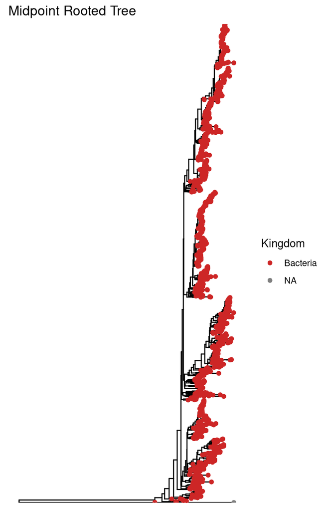

```r
# Quick inspection of tree
midpoint_rooted_tree_plot <-
  ggtree(midpoint_rooted_physeq) +
  geom_tippoint(mapping = aes(color = Kingdom)) +
  geom_tippoint(aes(color = Kingdom)) +
  labs(title = "Midpoint Rooted Tree") +
  scale_color_manual(values = c("firebrick3", "cornflowerblue", "grey"))

# Look at the tree
midpoint_rooted_tree_plot
```

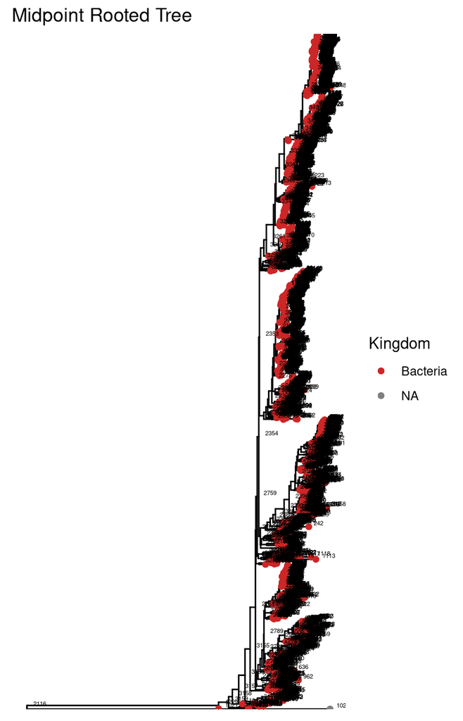

```r
# Add nodes
midpoint_rooted_tree_node_plot <-
  midpoint_rooted_tree_plot +
  geom_text(aes(label = node), hjust = -0.5, vjust = -0.3, size = 1.5)

# View it
midpoint_rooted_tree_node_plot
```

**INTERPRETATION #3 (If midpoint rooting): Now that you’ve rooted your tree, does the tree seem “finalized”? Are there any other branches/ASVs to inspect? Why or why not?** After midpoint rooting， the tree is more balanced and it seems “finalized”, but this does not necessarily mean the tree is truly finalized. There is no other branches/ASVs to inspect because the only long branch (#1020) has been inspected above.

## 7. Save phyloseq objects

### Save individual phyloseq objects

```r
# Save midpoint rooted phyloseq object
save(midpoint_rooted_physeq,
     file = "data/04_PhylogeneticTree/midpoint_rooted_physeq.RData")
```

# Final info for Reproducibility

## Check Render Time

```r
# Take the time now that we are at the end of the script
end_time <- Sys.time()
end_time
```

```
## [1] "2025-03-28 20:37:26 EDT"
```

```r
# Echo the elapsed time
elapsed_time <- round((end_time - start_time), 3)
elapsed_time
```

```
## Time difference of 17.666 secs
```